# Assignment 1: Data Preparation and Exploration

## Student Performance Dataset Analysis

This notebook is the assignment 1 submission of student s4134316, including the following steps: 1) data preparation, 2) data exploration, 3) missing value analysis, and 4) external data integration

**Dataset:** Modified Student Performance dataset from UCI Machine Learning Repository (Cortez & Silva, 2008; RMIT 2025)

# 1. Data Preparation

The data preparation workflow follows these key stages:

- Data Loading (1.1): Import the CSV file and verify its structure
- Initial Exploration (1.2): Examine data types, dimensions, and summary statistics
- Data Cleaning (1.3): including identify errors and clean the data (Standard and non-standard missing values), Sanity checks, typos, binary values check

## 1.1 Loading the Data

First, we load the CSV data file and verify its contents.

```
Dataset Shape: (650, 25)

Number of rows: 650
Number of columns: 25
```

```
Data Types:
school        object
sex           object
age           object
address       object
famsize       object
Medu           int64
Fedu           int64
Mjob          object
Fjob          object
reason        object
traveltime     int64
studytime     object
failures       int64
activities    object
higher        object
internet      object
romantic      object
famrel         int64
freetime       int64
goout          int64
health         int64
absences       int64
G1            object
G2            object
G3             int64
dtype: object

Column Names:
['school', 'sex', 'age', 'address', 'famsize', 'Medu', 'Fedu', 'Mjob', 'Fjob', 'reason', 'traveltime', 'studytime', 'failures', 'activities', 'higher', 'internet', 'romantic', 'famrel', 'freetime', 'goout', 'health', 'absences', 'G1', 'G2', 'G3']
```

## 1.2 Initial Data Exploration

|  | school | sex | age | address | famsize | Medu | Fedu | Mjob | Fjob | reason | ... | internet | romantic | famrel | freetime | goout | health | absences | G1 | G2 | G3 |
| --- | --- | --- | --- | --- | --- | --- | --- | --- | --- | --- | --- | --- | --- | --- | --- | --- | --- | --- | --- | --- | --- |
| count | 649 | 649 | 650 | 650 | 650 | 650.000000 | 650.000000 | 649 | 649 | 650 | ... | 650 | 650 | 650.000000 | 650.000000 | 650.000000 | 650.000000 | 650.000000 | 649 | 650 | 650.000000 |
| unique | 2 | 2 | 14 | 3 | 3 | NaN | NaN | 9 | 7 | 5 | ... | 3 | 3 | NaN | NaN | NaN | NaN | NaN | 20 | 17 | NaN |
| top | GP | F | 17 | U | GT3 | NaN | NaN | other | other | course | ... | yes | no | NaN | NaN | NaN | NaN | NaN | 10 | 11 | NaN |
| freq | 423 | 384 | 178 | 449 | 456 | NaN | NaN | 262 | 360 | 286 | ... | 500 | 407 | NaN | NaN | NaN | NaN | NaN | 93 | 103 | NaN |
| mean | NaN | NaN | NaN | NaN | NaN | 2.507692 | 2.307692 | NaN | NaN | NaN | ... | NaN | NaN | 3.930769 | 3.178462 | 3.183077 | 3.538462 | 3.729231 | NaN | NaN | 11.924615 |
| std | NaN | NaN | NaN | NaN | NaN | 1.135274 | 1.103616 | NaN | NaN | NaN | ... | NaN | NaN | 0.963018 | 1.051302 | 1.178397 | 1.448414 | 4.775765 | NaN | NaN | 3.242939 |
| min | NaN | NaN | NaN | NaN | NaN | 0.000000 | 0.000000 | NaN | NaN | NaN | ... | NaN | NaN | 1.000000 | 1.000000 | 1.000000 | 1.000000 | 0.000000 | NaN | NaN | 0.000000 |
| 25% | NaN | NaN | NaN | NaN | NaN | 2.000000 | 1.000000 | NaN | NaN | NaN | ... | NaN | NaN | 4.000000 | 3.000000 | 2.000000 | 2.000000 | 0.000000 | NaN | NaN | 10.000000 |
| 50% | NaN | NaN | NaN | NaN | NaN | 2.000000 | 2.000000 | NaN | NaN | NaN | ... | NaN | NaN | 4.000000 | 3.000000 | 3.000000 | 4.000000 | 2.000000 | NaN | NaN | 12.000000 |
| 75% | NaN | NaN | NaN | NaN | NaN | 4.000000 | 3.000000 | NaN | NaN | NaN | ... | NaN | NaN | 5.000000 | 4.000000 | 4.000000 | 5.000000 | 6.000000 | NaN | NaN | 14.000000 |
| max | NaN | NaN | NaN | NaN | NaN | 4.000000 | 4.000000 | NaN | NaN | NaN | ... | NaN | NaN | 5.000000 | 5.000000 | 5.000000 | 5.000000 | 32.000000 | NaN | NaN | 19.000000 |

11 rows × 25 columns

## 1.3 Data Cleaning

### 1.3.1 Detect Standard Missing Values before cleaning

```
Missing Values Before Cleaning:
           Missing Values  Percentage
school                  1    0.153846
sex                     1    0.153846
Mjob                    1    0.153846
Fjob                    1    0.153846
studytime               3    0.461538
G1                      1    0.153846
```

### 1.3.2 Detect Non-Standard Missing Values and Transform to Standard Missing Values (Numerical columns)

Check for non-standard missing value indicators (adapted from de Jonge & van der Loo (2013).

```
Non-standard missing values found and converted to NaN:

Column 'studytime':
  '-': 3 occurrences

Column 'G1':
  'X': 3 occurrences

Column 'G2':
  '-': 4 occurrences
```

### 1.3.3 Sanity Checks for Impossible Values

Validate data against UCI repository rules (Cortez & Silva, 2008) and transform impossible/out-of-range values to NaN.

**Valid Ranges of Numerical values:**

- `age`: 15-22 (student age in years)
- `absences`: 0-93 (number of school absences)
- `G1, G2, G3`: 0-20 (grades on 0-20 scale)

**Valid Ranges of Ordinal values**

- `studytime`: 1-4 (weekly study time)
- `famrel, freetime, goout, health`: 1-5 (ordinal scales)
- `Medu, Fedu, traveltime, studytime, failure`: 0-4 (parent education level)

**Source:** UCI Machine Learning Repository - Student Performance Dataset

```
Column 'age':
  Valid range: 15-22
  Found 5 invalid value(s): [np.float64(105.0), np.float64(106.0), np.float64(115.0), np.float64(170.0)]
  Converting to NaN...

Column 'G1':
  Valid range: 0-20
  Found 3 invalid value(s): [np.float64(123.0), np.float64(132.0)]
  Converting to NaN...

Column 'studytime':
  Valid range: 1-4
  Found 7 invalid value(s): [np.float64(6.0), np.float64(7.0), np.float64(8.0), np.float64(10.0), np.float64(11.0)]
  Converting to NaN...


Total columns with invalid values transformed: 3
```

### 1.3.4 Reidentify Rows with Missing Values

After all transformations (non-standard values and sanity checks), identify all rows that now contain standard missing values (NaN).

```
Total rows with missing values (after all transformations): 30

Row indices with missing values:
[21, 22, 73, 78, 102, 103, 104, 119, 120, 137, 138, 208, 209, 308, 309, 311, 319, 320, 324, 345, 346, 382, 383, 433, 434, 463, 555, 556, 592, 649]
```

### 1.3.5 Identifying & Transform Typos (Categorical columns)

```
  Column 'Mjob':
   Expected: ['teacher', 'health', 'services', 'at_home', 'other']
   Unexpected values found: ['service', 'at home', 'home', '0']
      - 'service': 3 occurrences
      - 'at home': 4 occurrences
      - 'home': 3 occurrences
      - '0': 1 occurrences

  Column 'Fjob':
   Expected: ['teacher', 'health', 'services', 'at_home', 'other']
   Unexpected values found: ['others', '0']
      - 'others': 5 occurrences
      - '0': 1 occurrences

  Column 'reason':
   Expected: ['home', 'reputation', 'course', 'other']
   Unexpected values found: ['0']
      - '0': 1 occurrences
```

```
Applying typo corrections...
============================================================

 Column 'Mjob':
    'service' → 'services' (3 occurrences)
    'home' → 'at_home' (3 occurrences)
    'at home' → 'at_home' (4 occurrences)
    '0' → 'nan' (1 occurrences)

 Column 'Fjob':
    'others' → 'other' (5 occurrences)
    '0' → 'nan' (1 occurrences)

 Column 'reason':
    '0' → 'nan' (1 occurrences)

============================================================
Transformation complete!
```

### 1.3.6 Validate Binary Categorical Variables & Ordinal Variables

```
Checking Binary Categorical Variables:
============================================================
✓ school: All values valid (['GP', 'MS'])
✓ sex: All values valid (['F', 'M'])

address: Found invalid values: ['0']
   Valid values should be: ['U', 'R']
   Value counts: {'U': 449, 'R': 200, '0': 1}

famsize: Found invalid values: ['0']
   Valid values should be: ['LE3', 'GT3']
   Value counts: {'GT3': 456, 'LE3': 193, '0': 1}

activities: Found invalid values: ['0']
   Valid values should be: ['yes', 'no']
   Value counts: {'no': 330, 'yes': 319, '0': 1}

higher: Found invalid values: ['0']
   Valid values should be: ['yes', 'no']
   Value counts: {'yes': 578, 'no': 71, '0': 1}

internet: Found invalid values: ['0']
   Valid values should be: ['yes', 'no']
   Value counts: {'yes': 500, 'no': 149, '0': 1}

romantic: Found invalid values: ['0']
   Valid values should be: ['yes', 'no']
   Value counts: {'no': 407, 'yes': 242, '0': 1}

Summary:
============================================================
- Binary categorical columns transformed: 8 columns
```

### 1.3.7 Summary of Data Changes

The following table comprehensively documents all data modifications performed during the cleaning process:

#### **Overview of Changes**

[output not shown]

#### **Rows Affected by Missing Values**

After all transformations, **30 rows** contain at least one missing value

#### **Data Integrity Verification**

- **Dataset shape maintained**: 650 rows × 25 columns (no rows dropped during cleaning)
- **All typos standardized**: Categorical values now match expected domain values
- **Invalid values flagged**: Out-of-range numerical values converted to NaN for proper handling
- **Missing values standardized**: All non-standard missing indicators converted to pandas NaN

**Conclusion**: The cleaned dataset (`df_cleaned`) now has standardized, validated data ready for analysis. Missing values are explicitly marked as NaN and will be addressed in Task 3 to compared with imputation techniques.

```
Cleaned dataframe saved to 'df_cleaned' variable.
```

# 2. Data Exploration

## 2.1 Visualization of Individual Variables

We will explore three different types of variables:

1. **Nominal Variable**: `Mjob` (Mother's job)
2. **Ordinal Variable**: `Medu` (Mother's education level: 0-4)
3. **Numerical Variable**: `G3` (Final grade)

### 2.1.1 Nominal Variable: Mother's Job (Mjob)

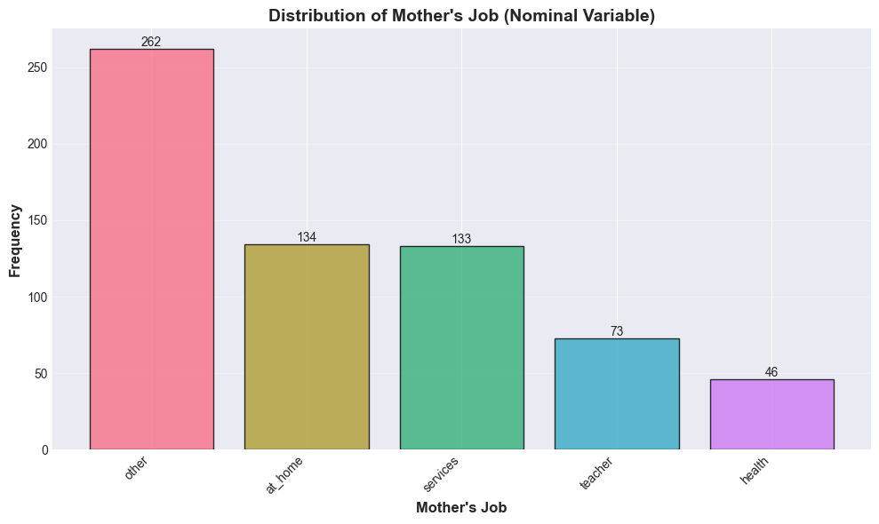

```
Mother's Job Distribution:
Mjob
other       262
at_home     134
services    133
teacher      73
health       46
Name: count, dtype: int64

Percentage Distribution:
Mjob
other       40.31
at_home     20.62
services    20.46
teacher     11.23
health       7.08
Name: count, dtype: float64
```

**Rationale for Selection Mother's job (`Mjob`):** is a nominal categorical variable illustrating the occupation of students' mothers. Parental occupation is a vital indicator of socioeconomic status, potentially influencing students academic achievement through students' available resources, parental involvement, and home learning environment (Berkowitz 2017). A bar chart appropriately visualizes the frequency distribution of nominal categories without implying false ordering.

### 2.1.2 Ordinal Variable: Mother's Education (Medu)

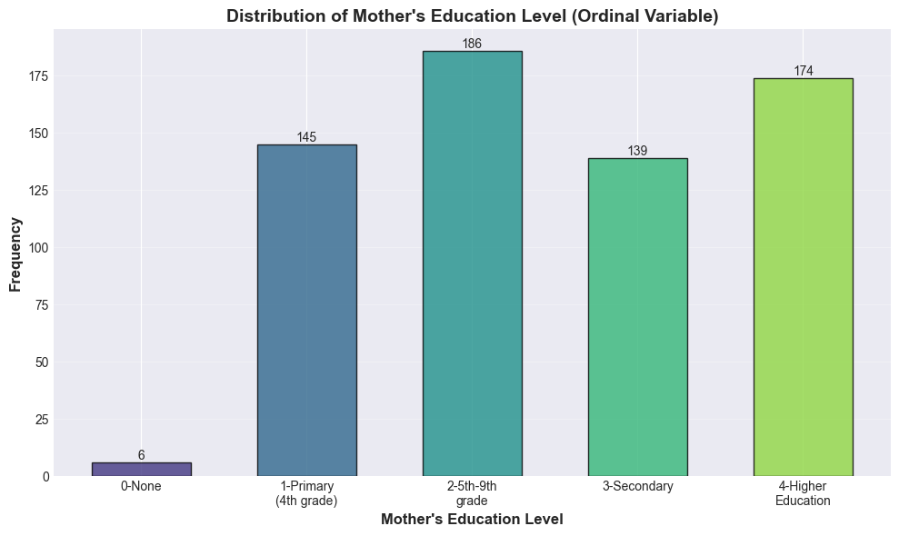

```
Mother's Education Level Distribution:
Medu
0      6
1    145
2    186
3    139
4    174
Name: count, dtype: int64

Mean Education Level: 2.51
Median Education Level: 2.0
```

**Rationale for Selection Mother's education (`Medu`):** this is an ordinal variable ranging from 0 (no education) to 4 (higher education). Maternal education is one of the most consistent predictors of children's academic success, including enriched home learning environments and more effective academic support and homework assistance (Hartas, 2011). An ordered bar chart preserves the ordinal ranking while displaying frequency distribution.

### 2.1.3 Numerical Variable: Final Grade (G3)

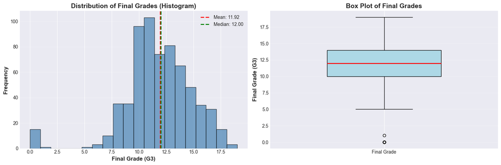

```
Final Grade (G3) Statistics:
Count: 650
Mean: 11.92
Median: 12.00
Std Dev: 3.24
Min: 0
Max: 19
Q1 (25%): 10.0
Q3 (75%): 14.0
IQR: 4.0
```

**Rationale for Selection:** Final grade (G3) is a continuous numerical variable (scale 0-20) representing the primary outcome measure of student academic performance.

**Key Observations:**

## 2.2 Exploring Relationships Between Variables

We will investigate three relationships with specific hypotheses:

### 2.2.1 Relationship 1: Study Time vs Final Grade

**Hypothesis:** Students who dedicate more time to studying (higher `studytime`) will achieve higher final grades (`G3`) (Credé and Kuncel 2008).

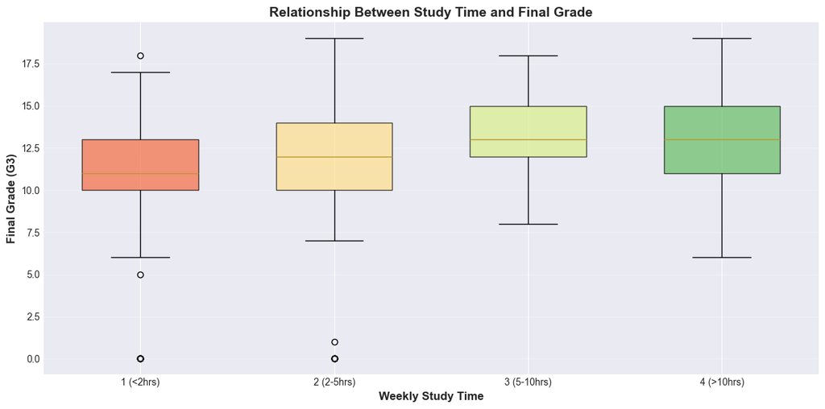

```
Mean Final Grade by Study Time:
Study Time 1: Mean Grade = 10.79, Count = 203
Study Time 2: Mean Grade = 12.05, Count = 301
Study Time 3: Mean Grade = 13.30, Count = 99
Study Time 4: Mean Grade = 13.09, Count = 34

ANOVA Test: F-statistic = 16.8863, p-value = 0.0000
Result: Significant difference in grades across study time groups (p < 0.05)
```

**Discussion:** The hypothesis is **strongly supported**. Students who dedicate more time to studying demonstrate significantly higher final grades, with ANOVA confirming highly significant differences across study time groups (F = 16.89, p < 0.0001).

Mean grades increase substantially from 10.79 for students studying less than 2 hours weekly (studytime = 1) to 13.30 for those studying 5-10 hours (studytime = 3), representing a 2.51-point improvement (23% increase). However, an interesting pattern emerges: students reporting the highest study time (>10 hours, studytime = 4) show slightly lower mean grades (13.09) than the studytime = 3 group, though this group has the smallest sample size (n = 34).

### 2.2.2 Relationship 2: Absences vs Final Grade

**Hypothesis:** Students with more absences will have lower final grades, as class attendance is crucial for learning (Credé and Roch 2010)

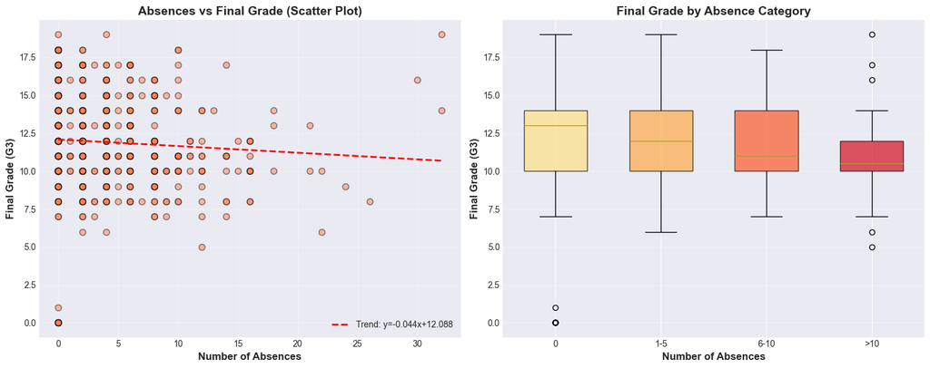

```
Pearson Correlation: r = -0.0646, p-value = 0.0999
Negative correlation: More absences associated with lower grades

Mean Grade by Absence Category:
Absences 0: Mean Grade = 12.04, Count = 245
Absences 1-5: Mean Grade = 12.03, Count = 229
Absences 6-10: Mean Grade = 11.94, Count = 126
Absences >10: Mean Grade = 10.82, Count = 50
```

**Discussion:** The hypothesis is **weakly supported**. While the data show a trend toward lower grades with increased absences, the overall correlation is very weak and not statistically significant (r = -0.065, p = 0.0999). Specifically, students with 0 absences (mean = 12.04) perform nearly identically to those with 1-5 absences (mean = 12.03) and 6-10 absences (mean = 11.94). Only students with more than 10 absences show notably lower performance (mean = 10.82), representing a 1.22-point decrease compared to perfect attenders (10% decline).

Several explanations are plausible: (1) **threshold effect** - occasional absences (1-10 days) may not substantially harm learning if students compensate through self-study, (2) **teaching quality** - if lectures add minimal value beyond textbook material, attendance matters less (Credé et al., 2010)

### 2.2.3 Relationship 3: Mother's Education vs Student's Final Grade

**Hypothesis:** Students whose mothers have higher education levels (`Medu`) will achieve higher final grades, reflecting the benefits of an educated home environment (Hartas 2011).

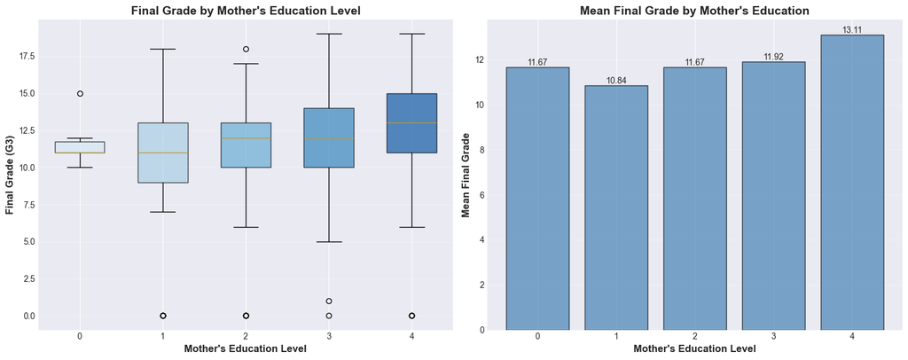

```
Mean Final Grade by Mother's Education Level:
Medu 0: Mean = 11.67, Std = 1.75, Count = 6
Medu 1: Mean = 10.84, Std = 3.16, Count = 145
Medu 2: Mean = 11.67, Std = 3.06, Count = 186
Medu 3: Mean = 11.92, Std = 3.12, Count = 139
Medu 4: Mean = 13.11, Std = 3.28, Count = 174

ANOVA Test: F-statistic = 10.8273, p-value = 0.0000

Spearman Correlation: r = 0.2814, p-value = 0.0000
```

**Discussion:** The hypothesis is **supported**. A statistically significant positive relationship exists (Spearman r = 0.28, p < 0.0001), with ANOVA confirming significant differences across education levels (F = 10.83, p < 0.0001).

Students whose mothers completed higher education (Medu = 4) achieve mean grades of 13.11, compared to 10.84 for students whose mothers have only primary education (Medu = 1), representing a 2.27-point improvement (21% increase). This suggests that university-educated mothers may provide qualitatively different forms of cultural capital, educational resources, and academic expectations that particularly benefit their children (Hartas 2011).

The 0.2814 correlation shows that maternal education explains approximately 8% of grade variance. High standard deviations within each education level (3.06-3.28) demonstrate substantial individual variation, reflecting the indirect pathways through which maternal education operates—via parental expectations.

## 2.3 Scatter Matrix for Numerical Variables

We will create a scatter matrix for three key numerical variables:

- `G1`: First period grade
- `G2`: Second period grade
- `G3`: Final grade

These grades represent student performance at different time points during the academic year.

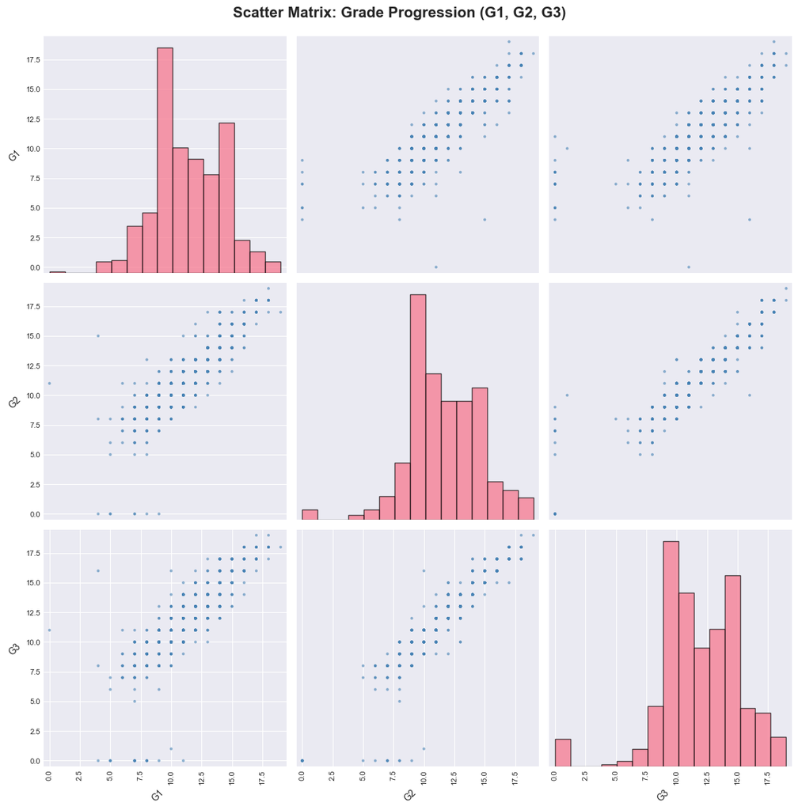

```
Correlation Matrix:
          G1        G2        G3
G1  1.000000  0.855367  0.817675
G2  0.855367  1.000000  0.919166
G3  0.817675  0.919166  1.000000
```

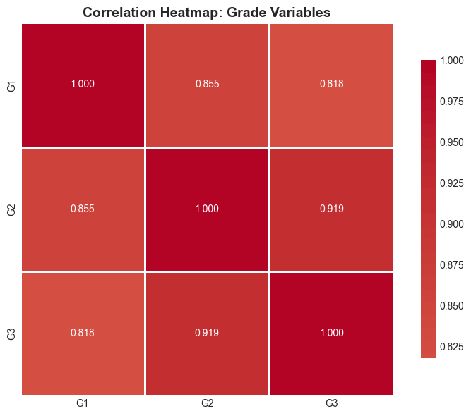

```
Grade Statistics:
               G1          G2          G3
count  639.000000  639.000000  639.000000
mean    11.377152   11.575900   11.907668
std      2.771922    2.931311    3.255945
min      0.000000    0.000000    0.000000
25%     10.000000   10.000000   10.000000
50%     11.000000   11.000000   12.000000
75%     13.000000   13.000000   14.000000
max     19.000000   19.000000   19.000000
```

**Analysis of Scatter Matrix:** The scatter matrix reveals **very strong** positive correlations between all three grade periods, around (0.818 -0.919).

More specifically, the G2-G3 correlation (0.919) is the strongest, demonstrating that second-period grades are highly predictive of final outcomes. This aligns with research showing "temporal proximity increases predictive accuracy" (Geiser & Santelices, 2007). The G1-G2 correlation (0.855) confirms students maintain consistent performance from the outset. Additionally, the strong G1-G3 correlation (0.818) validates early intervention strategies, as first-period performance reliably predicts final grades. Zimmermann et al. (2015) found that early academic metrics can explain over 54% of variance in later performance, supporting the use of G1 scores for identifying at-risk students.

For grade distributions, all three periods show similar patterns with means ranging from 11.38 (G1) to 11.91 (G3), indicating slight grade improvement over time. The medians (11-12) and interquartile ranges (10-13/14) are consistent across periods, suggesting stable performance distributions.

# 3. Analysis of Missing Values and Outliers

We clean the original dataset off missing values only (without other errors like typos, impossible values, ...), as required in the assignment prompt.

```
Standard missing values (NaN) after replacing non-standard indicators, ready to be imputed:
school       1
sex          1
age          2
Mjob         1
Fjob         1
studytime    3
G1           4
G2           4
dtype: int64

Data types after conversion:
age         float64
absences      int64
G1          float64
G2          float64
G3            int64
dtype: object
```

### 3.1.1 Approach 1: Mean Imputation

**Explanation of Mean Imputation:** Mean imputation replaces missing values in a numerical column with the arithmetic mean (average) of all non-missing values in that same column. This approach maintains the overall mean of the dataset and is computationally simple. It works by calculating the sum of all existing values divided by the count of non-missing entries, then filling all NaN/missing positions with this calculated mean value. This method is most appropriate when data is missing completely at random (MCAR) and the variable follows an approximately normal distribution (Little and Rubbin 2019). However, it reduces variance in the dataset and can underestimate standard deviation, as it does not account for the natural variability that would exist in the missing observations (Little and Rubbin 2019).

```
Missing values after mean imputation:
0

Mean imputation completed and saved to 'student_fix1.csv'
Dataset shape: (650, 25)

Mean values used for imputation:
age: 17.66
G1: 11.93
G2: 11.59
```

### 3.1.2 Approach 2: Median Imputation

**Explanation of Median Imputation:** Median imputation replaces missing values in a numerical column with the median of all non-missing values in that column (ascending order). This imputation method is more robust to outliers and skewed distributions, so it is particularly suitable for datasets with extreme values or non-normal distributions (Little and Rubbin 2019). It is preferred when the dataset contains outliers or when the distribution is skewed, as it provides a more representative "typical" value.

```
Missing values after median imputation:
0

Median imputation completed and saved to 'student_fix2.csv'
Dataset shape: (650, 25)

Median values used for imputation:
age: 17.00
G1: 11.00
G2: 11.00
```

### 3.1.3 Comparing Imputation Methods

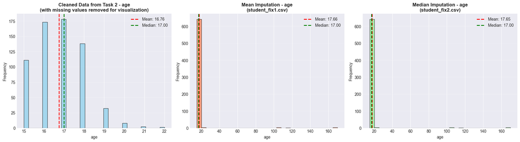

```
======================================================================
Statistical Comparison for 'age'
======================================================================

Metric               Original        Mean Imputation      Median Imputation
----------------------------------------------------------------------
Count                643             650                  650
Missing Values       7               0                    0
Mean                 16.76           17.66                17.65
Median               17.00           17.00                17.00
Std Deviation        1.23            10.59                10.59
Variance             1.52            112.20               112.21
Min                  15.00           15.00                15.00
Max                  22.00           170.00               170.00
======================================================================
```

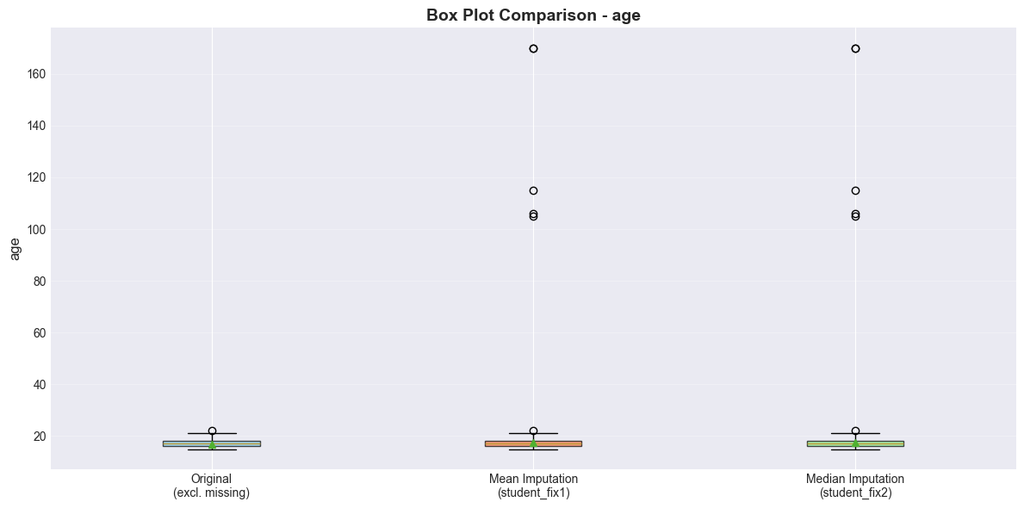

**Discussion of Impact:** **Comparison of Mean vs. Median Imputation**

**Visual and Statistical Impact:**

This leads to some statistical consequences, including Variance explosion (74x increase) and **8.6x increase** in Standard deviation. Simiarly, the maax value change from 22 to 170 years, indicating serious data quality problems in the original dataset, including extreme outliers (age = 170) that should have been cleaned before imputation. The choice between mean vs. median is irrelevant when such severe outliers exist.

## 3.2 Analysis of Outliers

### Question 1: Do outliers affect standard deviation?

**Answer:**

Outliers significantly affect standard deviation. Standard deviation measures the spread of data around the mean. Since it's calculated using squared differences from the mean, extreme values (outliers) have a disproportionately large impact. For example, in our age column (data_cleaned), without outliers, the std = 1.23, but with outliers present: std = 10.59 (8.6x increase) A single extreme value like age = 170 dramatically inflates the standard deviation, making it unreliable as a measure of typical variability (Allison, 2009). This is why the median and interquartile range (IQR) are preferred for datasets with outliers - they are robust statistics that aren't influenced by extreme values.

### Question 2: When should an outlier NOT be removed?

**Answer** According to Frost (2024), there are several outliers that should not be removed:

- Legitimate Data Points: When the outlier represents a real, valid observation rather than a measurement error Eg. A 22-year-old student in high school is unusual but possible (repeated grades, late enrollment)
- Small Sample Sizes: Removing outliers from small datasets can eliminate meaningful variation and reduce statistical power
- Natural Variation: When outliers are part of the genuine population distribution Eg. In income data, billionaires are extreme outliers but represent real economic inequality
- Domain Requirements: When the analysis specifically requires understanding extreme cases Eg. Risk assessment or fraud detection needs to study outliers However, it is most effective to leverage sensitivity analysis, in which data is analyzed both with and without outliers to understand their impact, rather than automatically removing them (Thabane et al. 2013).

### Question 3: Detecting Outliers in the Dataset

We will apply three statistical methods to detect outliers:

- Method 1: IQR Method

```
====================================================================================================
METHOD 1: IQR METHOD (Outliers are values outside Q1 - 1.5×IQR and Q3 + 1.5×IQR)
====================================================================================================

AGE:
  Q1: 16.00 | Q3: 18.00 | IQR: 2.00
  Lower bound: 13.00 | Upper bound: 21.00
  Number of outliers: 1 (0.15% of data)
  Outlier values: [np.float64(22.0)]
  Min outlier: 22.00 | Max outlier: 22.00

ABSENCES:
  Q1: 0.00 | Q3: 6.00 | IQR: 6.00
  Lower bound: -9.00 | Upper bound: 15.00
  Number of outliers: 22 (3.38% of data)
  Outlier values: [np.int64(16), np.int64(18), np.int64(21), np.int64(22), np.int64(24), np.int64(26), np.int64(30), np.int64(32)]
  Min outlier: 16.00 | Max outlier: 32.00

G1:
  Q1: 10.00 | Q3: 13.00 | IQR: 3.00
  Lower bound: 5.50 | Upper bound: 17.50
  Number of outliers: 17 (2.62% of data)
  Outlier values: [np.float64(0.0), np.float64(4.0), np.float64(5.0), np.float64(18.0), np.float64(19.0)]
  Min outlier: 0.00 | Max outlier: 19.00

G2:
  Q1: 10.00 | Q3: 13.00 | IQR: 3.00
  Lower bound: 5.50 | Upper bound: 17.50
  Number of outliers: 26 (4.00% of data)
  Outlier values: [np.float64(0.0), np.float64(5.0), np.float64(18.0), np.float64(19.0)]
  Min outlier: 0.00 | Max outlier: 19.00

G3:
  Q1: 10.00 | Q3: 14.00 | IQR: 4.00
  Lower bound: 4.00 | Upper bound: 20.00
  Number of outliers: 16 (2.46% of data)
  Outlier values: [np.int64(0), np.int64(1)]
  Min outlier: 0.00 | Max outlier: 1.00
```

```
====================================================================================================
METHOD 2: Z-SCORE METHOD (Outliers are values with |Z-score| > 3)
====================================================================================================

AGE:
  Mean: 16.76 | Std Dev: 1.23
  Number of outliers: 3 (0.46% of data)
  Outlier values: [np.float64(21.0), np.float64(22.0)]
  Z-scores range: 3.45 to 4.26

ABSENCES:
  Mean: 3.73 | Std Dev: 4.78
  Number of outliers: 9 (1.38% of data)
  Outlier values: [np.int64(21), np.int64(22), np.int64(24), np.int64(26), np.int64(30), np.int64(32)]
  Z-scores range: 3.62 to 5.92

G1:
  Mean: 11.38 | Std Dev: 2.77
  Number of outliers: 1 (0.15% of data)
  Outlier values: [np.float64(0.0)]
  Z-scores range: 4.12 to 4.12

G2:
  Mean: 11.59 | Std Dev: 2.93
  Number of outliers: 7 (1.08% of data)
  Outlier values: [np.float64(0.0)]
  Z-scores range: 3.96 to 3.96

G3:
  Mean: 11.92 | Std Dev: 3.24
  Number of outliers: 16 (2.46% of data)
  Outlier values: [np.int64(0), np.int64(1)]
  Z-scores range: 3.37 to 3.68
```

```
====================================================================================================
METHOD 3: BOX PLOT VISUALIZATION
====================================================================================================
Generating box plots... (outliers shown as individual points beyond whiskers)
```

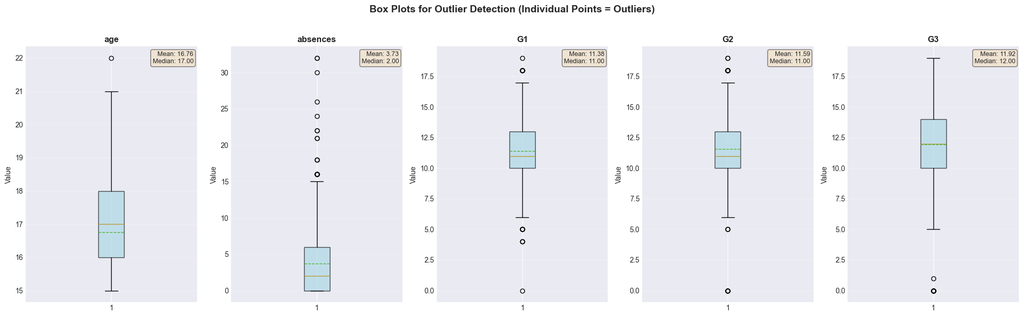

```
====================================================================================================
DETAILED OUTLIER VALUES BY METHOD
====================================================================================================

AGE:
  IQR Method outliers: [np.float64(22.0)]
  Z-Score Method outliers: [np.float64(21.0), np.float64(22.0)]
  Outliers detected by BOTH methods: 1 observations
  Values: [np.float64(22.0)]

ABSENCES:
  IQR Method outliers: [np.int64(16), np.int64(18), np.int64(21), np.int64(22), np.int64(24), np.int64(26), np.int64(30), np.int64(32)]
  Z-Score Method outliers: [np.int64(21), np.int64(22), np.int64(24), np.int64(26), np.int64(30), np.int64(32)]
  Outliers detected by BOTH methods: 9 observations
  Values: [np.int64(21), np.int64(22), np.int64(24), np.int64(26), np.int64(30), np.int64(32)]

G1:
  IQR Method outliers: [np.float64(0.0), np.float64(4.0), np.float64(5.0), np.float64(18.0), np.float64(19.0)]
  Z-Score Method outliers: [np.float64(0.0)]
  Outliers detected by BOTH methods: 1 observations
  Values: [np.float64(0.0)]

G2:
  IQR Method outliers: [np.float64(0.0), np.float64(5.0), np.float64(18.0), np.float64(19.0)]
  Z-Score Method outliers: [np.float64(0.0)]
  Outliers detected by BOTH methods: 7 observations
  Values: [np.float64(0.0)]

G3:
  IQR Method outliers: [np.int64(0), np.int64(1)]
  Z-Score Method outliers: [np.int64(0), np.int64(1)]
  Outliers detected by BOTH methods: 16 observations
  Values: [np.int64(0), np.int64(1)]

====================================================================================================
COMPARISON: IQR METHOD vs Z-SCORE METHOD
====================================================================================================

   Column  IQR Outliers  Z-Score Outliers IQR % Z-Score %
     age             1                 3 0.15%     0.46%
absences            22                 9 3.38%     1.38%
      G1            17                 1 2.62%     0.15%
      G2            26                 7 4.00%     1.08%
      G3            16                16 2.46%     2.46%
```

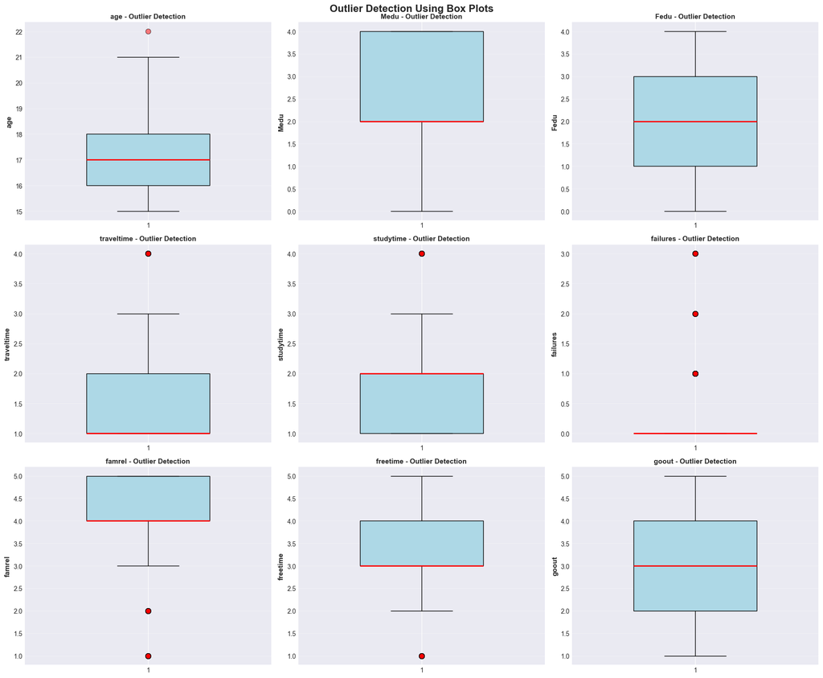

**Outlier Detection Methods Explained**

**Recommendations**

- DO **NOT** remove any outliers (which are in allowed range). All detected values represent legitimate educational variation:
- Older students are possible in secondary education High absences reflect real student crises requiring intervention Extreme grades (both 0 and 18-19) represent actual performance spectrum
- Use IQR for comprehensive analysis and Z-score to identify critical cases (grade 0, 30+ absences). Values flagged by both methods warrant immediate attention. These outliers provide crucial insights into at-risk students and shouldn't be deleted but rather investigated for targeted support interventions.

## Task 3.3: Hidden Data Quality Issues

### What Can Be Hidden Data Quality Issues?

**1) Logical Inconsistencies**

Values that don't violate range constraints individually but are impossible in combination. In this case, I will analyze grade progression and study time relationships Example: Detect consistently declining grades or students with low study time but had high grades (which could indicate high aptitude or underreported study => need further data)

```
Logical Consistency:
  Consistently declining grades: 8 students
  Low study time + high grades: 13 students

======================================================================
```

**2) Duplicates**

Multiple entries for the same entity with slight or no variation => we need studentIDs to double check if these are duplicates or not.

```
[2] Duplicate Records:
  Exact duplicates that may require further checks: 6
```

# 4. External Data: MovieLens 100K Dataset

## 4.1 Data Retrieval

We will download and work with the MovieLens 100K dataset from GroupLens Research.

```
Downloading MovieLens 100K dataset...
✓ Download complete

Extracting files...
✓ Extraction complete

Checking for required files...
✓ u.data found
✓ u.item found
```

## 4.2 Loading and Exploring u.data

The `u.data` file contains the core ratings information with 100,000 entries.

**File Format:** Tab-separated values  
**Columns:** user_id, item_id, rating, timestamp  
**Encoding:** latin-1

```
u.data (Ratings Data):
Shape: (100000, 4)

Data types:
user_id      int64
item_id      int64
rating       int64
timestamp    int64
dtype: object

Basic statistics:
            user_id        item_id         rating     timestamp
count  100000.00000  100000.000000  100000.000000  1.000000e+05
mean      462.48475     425.530130       3.529860  8.835289e+08
std       266.61442     330.798356       1.125674  5.343856e+06
min         1.00000       1.000000       1.000000  8.747247e+08
25%       254.00000     175.000000       3.000000  8.794487e+08
50%       447.00000     322.000000       4.000000  8.828269e+08
75%       682.00000     631.000000       4.000000  8.882600e+08
max       943.00000    1682.000000       5.000000  8.932866e+08
```

## 4.3 Loading and Exploring u.item

The `u.item` file contains metadata about each movie including title, release date, and genre classifications.

**File Format:** Pipe-separated values (|)  
**Columns:** movie_id, title, release_date, video_release_date, IMDb_URL, + 19 genre binary flags  
**Encoding:** latin-1

```
u.item (Movie Data):
Shape: (1682, 24)

Data types:
movie_id                int64
title                  object
release_date           object
video_release_date    float64
IMDb_URL               object
unknown                 int64
Action                  int64
Adventure               int64
Animation               int64
Children                int64
Comedy                  int64
Crime                   int64
Documentary             int64
Drama                   int64
Fantasy                 int64
Film-Noir               int64
Horror                  int64
Musical                 int64
Mystery                 int64
Romance                 int64
Sci-Fi                  int64
Thriller                int64
War                     int64
Western                 int64
dtype: object

Column names:
['movie_id', 'title', 'release_date', 'video_release_date', 'IMDb_URL', 'unknown', 'Action', 'Adventure', 'Animation', 'Children', 'Comedy', 'Crime', 'Documentary', 'Drama', 'Fantasy', 'Film-Noir', 'Horror', 'Musical', 'Mystery', 'Romance', 'Sci-Fi', 'Thriller', 'War', 'Western']
```

## 4.4 Merging the Datasets

We will merge the ratings data with movie information to create a comprehensive dataset for analysis.

**Join Strategy:** Left join on `item_id` (ratings) = `movie_id` (movies)  
**Expected Result:** Each rating will be enriched with the corresponding movie's title and genre information

```
Merged Dataset:
Shape: (100000, 28)

First 5 rows:
   user_id  item_id  rating  timestamp  movie_id                       title  \
0      196      242       3  881250949       242                Kolya (1996)
1      186      302       3  891717742       302    L.A. Confidential (1997)
2       22      377       1  878887116       377         Heavyweights (1994)
3      244       51       2  880606923        51  Legends of the Fall (1994)
4      166      346       1  886397596       346         Jackie Brown (1997)

  release_date  video_release_date  \
0  24-Jan-1997                 NaN
1  01-Jan-1997                 NaN
2  01-Jan-1994                 NaN
3  01-Jan-1994                 NaN
4  01-Jan-1997                 NaN

                                            IMDb_URL  unknown  ...  Fantasy  \
0    http://us.imdb.com/M/title-exact?Kolya%20(1996)        0  ...        0
1  http://us.imdb.com/M/title-exact?L%2EA%2E+Conf...        0  ...        0
2  http://us.imdb.com/M/title-exact?Heavyweights%...        0  ...        0
3  http://us.imdb.com/M/title-exact?Legends%20of%...        0  ...        0
4  http://us.imdb.com/M/title-exact?imdb-title-11...        0  ...        0

   Film-Noir  Horror  Musical  Mystery  Romance  Sci-Fi  Thriller  War  \
0          0       0        0        0        0       0         0    0
1          1       0        0        1        0       0         1    0
2          0       0        0        0        0       0         0    0
3          0       0        0        0        1       0         0    1
4          0       0        0        0        0       0         0    0

   Western
0        0
1        0
2        0
3        1
4        0

[5 rows x 28 columns]

Column names (28 total):
['user_id', 'item_id', 'rating', 'timestamp', 'movie_id', 'title', 'release_date', 'video_release_date', 'IMDb_URL', 'unknown', 'Action', 'Adventure', 'Animation', 'Children', 'Comedy', 'Crime', 'Documentary', 'Drama', 'Fantasy', 'Film-Noir', 'Horror', 'Musical', 'Mystery', 'Romance', 'Sci-Fi', 'Thr…

Merge quality check:
Rows in ratings: 100000
Rows in merged: 100000
Unmatched ratings: 0
```

## 4.5 Data Quality Assessment

We will perform comprehensive data quality checks on the merged dataset to identify potential issues.

```
Missing Values in Merged Dataset:
               Column  Missing_Count  Percentage
6        release_date              9       0.009
7  video_release_date         100000     100.000
8            IMDb_URL             13       0.013

Duplicate rows: 0

Rating Statistics:
count    100000.000000
mean          3.529860
std           1.125674
min           1.000000
25%           3.000000
50%           4.000000
75%           4.000000
max           5.000000
Name: rating, dtype: float64

Rating Distribution:
rating
1     6110
2    11370
3    27145
4    34174
5    21201
Name: count, dtype: int64
```

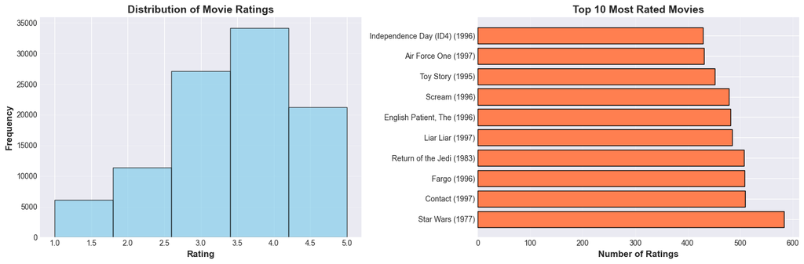

## 4.6 Data Preparation Summary

As explored, I found that there are missing release dates for some movies, video release dates largely empty, and Timestamps are Unix epoch format (must be converted to datetime). For the next steps, I will convert timestamps to readable date format and analyze genre preferences. After that, I will build user-movie matrices for recommendation systems.

# 5. Reference

Allison, P. D. (2009). Missing data. In R. E. Millsap & A. Maydeu-Olivares (Eds.), The SAGE handbook of quantitative methods in psychology (pp. 72-89). Sage Publications.

Berkowitz, R., Moore, H., Astor, R. A., & Benbenishty, R. (2017). A research synthesis of the associations between socioeconomic background, inequality, school climate, and academic achievement. *Review of Educational Research*, 87(2), 425-469. https://doi.org/10.3102/0034654316669821

Brookhart, S. M., Guskey, T. R., Bowers, A. J., McMillan, J. H., Smith, J. K., Smith, L. F., Stevens, M. T., & Welsh, M. E. (2016). A century of grading research: Meaning and value in the most common educational measure. *Review of Educational Research*, 86(4), 803-848. https://doi.org/10.3102/0034654316672069

Credé, M., & Kuncel, N. R. (2008). Study habits, skills, and attitudes: The third pillar supporting collegiate academic performance. *Perspectives on Psychological Science*, 3(6), 425-453. https://doi.org/10.1111/j.1745-6924.2008.00089.x

Credé, M., Roch, S. G., & Kieszczynka, U. M. (2010). Class attendance in college: A meta-analytic review of the relationship of class attendance with grades and student characteristics. *Review of Educational Research*, 80(2), 272-295. https://doi.org/10.3102/0034654310362998

Frost, J. (2024, April 25). Guidelines for removing and handling outliers in data. Statistics By Jim. https://statisticsbyjim.com/basics/remove-outliers/

Hartas, D. (2011). Families' social backgrounds matter: Socio-economic factors, home learning and young children's language, literacy and social outcomes. *British Educational Research Journal*, 37(6), 893-914. https://doi.org/10.1080/01411926.2010.506945

Jonge, E. de, & Loo, M. van der (2013). An introduction to data cleaning with R. *Statistics Netherlands Discussion Paper* (201313). Statistics Netherlands, The Hague. https://www.cbs.nl/en-gb/background/2013/13/an-introduction-to-data-cleaning-with-r

Kang, H. (2013). The prevention and handling of the missing data. Korean Journal of Anesthesiology, 64(5), 402-406. https://doi.org/10.4097/kjae.2013.64.5.402

Lee, K. J., & Carlin, J. B. (2010). Multiple imputation for missing data: Fully conditional specification versus multivariate normal imputation. American Journal of Epidemiology, 171(5), 624-632. https://doi.org/10.1093/aje/kwp425

Little, R. J., & Rubin, D. B. (2019). Statistical analysis with missing data (3rd ed.). John Wiley & Sons. https://doi.org/10.1002/9781119482260

Thabane, L., Mbuagbaw, L., Zhang, S., Samaan, Z., Marcucci, M., Ye, C., Thabane, M., Giangregorio, L., Dennis, B., Kosa, D., Debono, V. B., Dillenburg, R., Fruci, V., Bawor, M., Lee, J., Wells, G., & Goldsmith, C. H. (2013). A tutorial on sensitivity analyses in clinical trials: The what, why, when and how. BMC Medical Research Methodology, 13, 92. https://doi.org/10.1186/1471-2288-13-92